# Part I - DATA ANALYSIS ON THE PISA DATASET

## Introduction

> This is a dataset which examines how well students have learned the school curricullum and how well prepared they are for life beyond school, all from 510,000 students in 65 economies took part in the PISA 2012 assessment of reading, mathematics and science. Of those economies, 44 took part in an assessment of creative problem solving and 18 in an assessment of financial literacy.

## Preliminary Wrangling

```python
# import all packages and set plots to be embedded inline
import numpy as np
import pandas as pd
import matplotlib.pyplot as plt
import seaborn as sb

%matplotlib inline
```

> Load in your dataset and describe its properties through the questions below. Try and motivate your exploration goals through this section.

```python
df = pd.read_csv('pisa2012.csv', sep=',')
df.head()
```

|  | Unnamed: 0 | CNT | SUBNATIO | STRATUM | OECD | NC | SCHOOLID | STIDSTD | ST01Q01 | ST02Q01 | ... | W_FSTR75 | W_FSTR76 | W_FSTR77 | W_FSTR78 | W_FSTR79 | W_FSTR80 | WVARSTRR | VAR_UNIT | SENWGT_STU | VER_STU |
| --- | --- | --- | --- | --- | --- | --- | --- | --- | --- | --- | --- | --- | --- | --- | --- | --- | --- | --- | --- | --- | --- |
| 0 | 1 | Albania | 80000 | ALB0006 | Non-OECD | Albania | 1 | 1 | 10 | 1.0 | ... | 13.7954 | 13.9235 | 13.1249 | 13.1249 | 4.3389 | 13.0829 | 19 | 1 | 0.2098 | 22NOV13 |
| 1 | 2 | Albania | 80000 | ALB0006 | Non-OECD | Albania | 1 | 2 | 10 | 1.0 | ... | 13.7954 | 13.9235 | 13.1249 | 13.1249 | 4.3389 | 13.0829 | 19 | 1 | 0.2098 | 22NOV13 |
| 2 | 3 | Albania | 80000 | ALB0006 | Non-OECD | Albania | 1 | 3 | 9 | 1.0 | ... | 12.7307 | 12.7307 | 12.7307 | 12.7307 | 4.2436 | 12.7307 | 19 | 1 | 0.1999 | 22NOV13 |
| 3 | 4 | Albania | 80000 | ALB0006 | Non-OECD | Albania | 1 | 4 | 9 | 1.0 | ... | 12.7307 | 12.7307 | 12.7307 | 12.7307 | 4.2436 | 12.7307 | 19 | 1 | 0.1999 | 22NOV13 |
| 4 | 5 | Albania | 80000 | ALB0006 | Non-OECD | Albania | 1 | 5 | 9 | 1.0 | ... | 12.7307 | 12.7307 | 12.7307 | 12.7307 | 4.2436 | 12.7307 | 19 | 1 | 0.1999 | 22NOV13 |

5 rows × 636 columns

```python
# Keeping columns I feel are most important to the analysis

cols = ['STIDSTD','ST04Q01','CNT','PV1MATH','PV1READ','PV1SCIE','ST11Q01','ST11Q02','ST57Q05','HISCED','IMMIG']

df = df[cols]
```

```python
# checking for duplicated data

df.duplicated().any()
```

```
False
```

```python
# checking for null data

df.isnull().any()
```

```
STIDSTD    False
ST04Q01    False
CNT        False
PV1MATH    False
PV1READ    False
PV1SCIE    False
ST11Q01     True
ST11Q02     True
ST57Q05     True
HISCED      True
IMMIG       True
dtype: bool
```

```python
# dropping null data

df.dropna(inplace=True)
df.isnull().any()
```

```
STIDSTD    False
ST04Q01    False
CNT        False
PV1MATH    False
PV1READ    False
PV1SCIE    False
ST11Q01    False
ST11Q02    False
ST57Q05    False
HISCED     False
IMMIG      False
dtype: bool
```

Renaming columns for easy readability

```python
df.rename({'STIDSTD':'Student Id', 'ST04Q01':'Gender','CNT':'Country',
             'PV1MATH':'Math Score', 'PV1READ':"Reading Score",'PV1SCIE':'Science Score',
             'ST11Q01':'Mother Present', 'ST11Q02':'Father Present', 'ST57Q05':'Study Time With Parent',
             'HISCED':'Parents Highest Education', 'IMMIG':'Immigration Status'
            },
            axis='columns', inplace=True)
```

```python
df.head()
```

|  | Student Id | Gender | Country | Math Score | Reading Score | Science Score | Mother Present | Father Present | Study Time With Parent | Parents Highest Education | Immigration Status |
| --- | --- | --- | --- | --- | --- | --- | --- | --- | --- | --- | --- |
| 1 | 2 | Female | Albania | 486.1427 | 406.2936 | 548.9929 | Yes | Yes | 0.0 | ISCED 5A, 6 | Native |
| 2 | 3 | Female | Albania | 533.2684 | 401.2100 | 499.6643 | Yes | Yes | 2.0 | ISCED 5A, 6 | Native |
| 3 | 4 | Female | Albania | 412.2215 | 547.3630 | 438.6796 | Yes | Yes | 0.0 | ISCED 5A, 6 | Native |
| 5 | 6 | Female | Albania | 396.3312 | 378.2544 | 384.3156 | Yes | Yes | 1.0 | ISCED 3B, C | Native |
| 6 | 7 | Female | Albania | 438.0823 | 373.2503 | 508.1499 | Yes | Yes | 0.0 | ISCED 5A, 6 | Native |

```python
df.info()
```

```
<class 'pandas.core.frame.DataFrame'>
Int64Index: 258484 entries, 1 to 485489
Data columns (total 11 columns):
 #   Column                     Non-Null Count   Dtype
---  ------                     --------------   -----
 0   Student Id                 258484 non-null  int64
 1   Gender                     258484 non-null  object
 2   Country                    258484 non-null  object
 3   Math Score                 258484 non-null  float64
 4   Reading Score              258484 non-null  float64
 5   Science Score              258484 non-null  float64
 6   Mother Present             258484 non-null  object
 7   Father Present             258484 non-null  object
 8   Study Time With Parent     258484 non-null  float64
 9   Parents Highest Education  258484 non-null  object
 10  Immigration Status         258484 non-null  object
dtypes: float64(4), int64(1), object(6)
memory usage: 23.7+ MB
```

I discovered a tidiness issue being, parents presence being in two separate columns

```python
df['Parents Presence'] = ((df['Mother Present'] == 'No') | (df['Father Present'] == 'No')).replace(False, 'Both').replace(True, 'Single')

#dropping the former columns
df = df.drop(['Mother Present','Father Present'], axis=1)
```

Type issues:

- Study Time With Parent is a float64 instead of an int64
- Gender, ParentsHighestEducation and ImmigrationStatus are meant to be categories

```python
# no 1
df['Study Time With Parent'] = df['Study Time With Parent'].astype('int64')

# no 2
gender_dtype = pd.api.types.CategoricalDtype(categories=['Female','Male'])
df['Gender'] = df['Gender'].astype(gender_dtype)

# no 3
parents_presence_dtype = pd.api.types.CategoricalDtype(categories=['Both','Single'])
df['Parents Presence'] = df['Parents Presence'].astype(parents_presence_dtype)

# no 4
parentHE_dtype = pd.api.types.CategoricalDtype(
                    categories=['None','ISCED 1','ISCED 2','ISCED 3B, C','ISCED 3A, ISCED 4','ISCED 5B','ISCED 5A, 6'],
                    ordered=True)
df['Parents Highest Education'] = df['Parents Highest Education'].astype(parentHE_dtype)

# no 5
immig_dtype = pd.api.types.CategoricalDtype(categories=['Native','Second-Generation','First-Generation'], ordered=True)
df['Immigration Status'] = df['Immigration Status'].astype(immig_dtype)
```

```python
df.dtypes
```

```
Student Id                      int64
Gender                       category
Country                        object
Math Score                    float64
Reading Score                 float64
Science Score                 float64
Study Time With Parent          int64
Parents Highest Education    category
Immigration Status           category
Parents Presence             category
dtype: object
```

I want to calculate the average score for each student

```python
df['Average Score'] = (df['Math Score'] + df['Reading Score'] + df['Science Score']) / 3
df.head()
```

|  | Student Id | Gender | Country | Math Score | Reading Score | Science Score | Study Time With Parent | Parents Highest Education | Immigration Status | Parents Presence | Average Score |
| --- | --- | --- | --- | --- | --- | --- | --- | --- | --- | --- | --- |
| 1 | 2 | Female | Albania | 486.1427 | 406.2936 | 548.9929 | 0 | ISCED 5A, 6 | Native | Both | 480.476400 |
| 2 | 3 | Female | Albania | 533.2684 | 401.2100 | 499.6643 | 2 | ISCED 5A, 6 | Native | Both | 478.047567 |
| 3 | 4 | Female | Albania | 412.2215 | 547.3630 | 438.6796 | 0 | ISCED 5A, 6 | Native | Both | 466.088033 |
| 5 | 6 | Female | Albania | 396.3312 | 378.2544 | 384.3156 | 1 | ISCED 3B, C | Native | Both | 386.300400 |
| 6 | 7 | Female | Albania | 438.0823 | 373.2503 | 508.1499 | 0 | ISCED 5A, 6 | Native | Both | 439.827500 |

```python
df.head()
```

|  | Student Id | Gender | Country | Math Score | Reading Score | Science Score | Study Time With Parent | Parents Highest Education | Immigration Status | Parents Presence | Average Score |
| --- | --- | --- | --- | --- | --- | --- | --- | --- | --- | --- | --- |
| 1 | 2 | Female | Albania | 486.1427 | 406.2936 | 548.9929 | 0 | ISCED 5A, 6 | Native | Both | 480.476400 |
| 2 | 3 | Female | Albania | 533.2684 | 401.2100 | 499.6643 | 2 | ISCED 5A, 6 | Native | Both | 478.047567 |
| 3 | 4 | Female | Albania | 412.2215 | 547.3630 | 438.6796 | 0 | ISCED 5A, 6 | Native | Both | 466.088033 |
| 5 | 6 | Female | Albania | 396.3312 | 378.2544 | 384.3156 | 1 | ISCED 3B, C | Native | Both | 386.300400 |
| 6 | 7 | Female | Albania | 438.0823 | 373.2503 | 508.1499 | 0 | ISCED 5A, 6 | Native | Both | 439.827500 |

```python
df.shape
```

```
(258484, 11)
```

### What is the structure of your dataset?

> A dataset of 11 features and 258484 student results.

### What is/are the main feature(s) of interest in your dataset?

> I would like to know what parental factors affect student scores the most.

### What features in the dataset do you think will help support your investigation into your feature(s) of interest?

> Based on the fact parents are given in this dataset, I think:
> 1. the time the parent spends working with the student
> 2. the level of education of the parents
> 3. the presence of the parents at home

## Univariate Exploration

### 1. How much time does the parent spend working with the student?

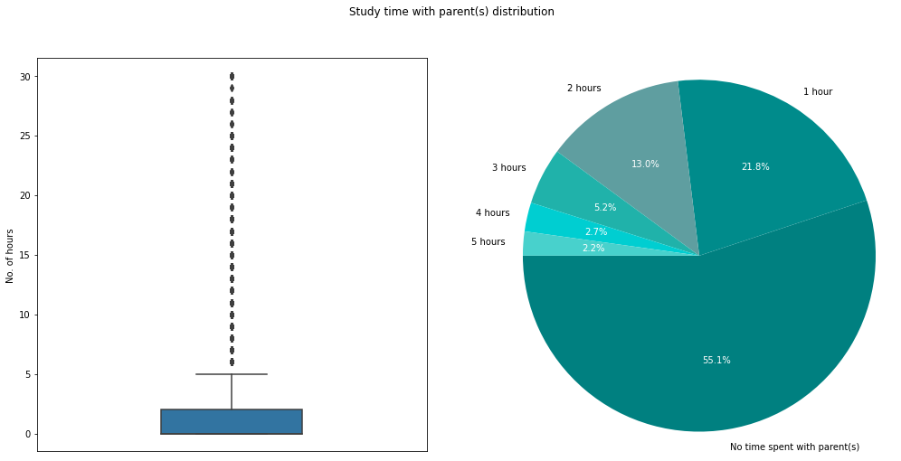

```python
fig1, ax1 = plt.subplots(1, 2, figsize=(17, 8), sharex=True)

sb.boxplot(y=df['Study Time With Parent'], ax=ax1[0]);
ax1[0].set(ylabel='No. of hours')

five = df[df['Study Time With Parent'] < 6]['Study Time With Parent'].value_counts()

patches, texts, autotexts = ax1[1].pie(five,
                                    colors = ['#008080','#008B8B','#5F9EA0','#20B2AA','#00CED1','#48D1CC'],
                                    labels=['No time spent with parent(s)', '1 hour', '2 hours', '3 hours', '4 hours', '5 hours'],
                                    autopct='%1.1f%%',
                                    startangle=180
                                   );
for text in autotexts:
    text.set_color('white')
ax1[1].axis('equal');

plt.suptitle('Study time with parent(s) distribution')
plt.show();
```

### 2. Level of education of the parents

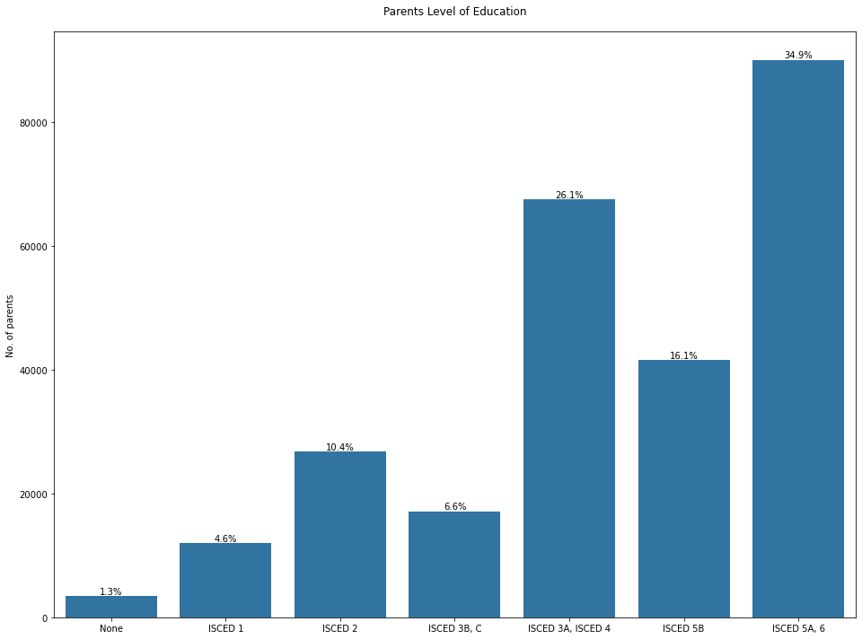

```python
plt.figure(figsize=[16, 12]);
sb.countplot(x = 'Parents Highest Education', data = df, color = sb.color_palette()[0]);

n_points = df.shape[0]
cat_counts = df['Parents Highest Education'].value_counts()
locs, labels = plt.xticks()

for loc, label in zip(locs, labels):

    count = cat_counts[label.get_text()]
    pct_string = '{:0.1f}%'.format(100*count/n_points)

    plt.text(loc, count-8, pct_string, ha = 'center', va='bottom', color = 'black')

plt.ylabel('No. of parents');
plt.xlabel('');
plt.title('Parents Level of Education', y = 1.02);
```

### 3. Parent Presence

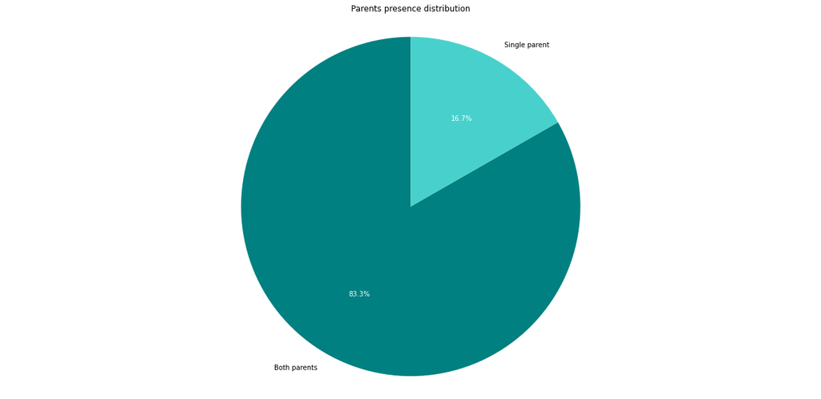

```python
fig1, ax1 = plt.subplots(1, 1, figsize=(17, 8), sharex=True)
patches, texts, autotexts = ax1.pie(df['Parents Presence'].value_counts(),
                                    colors = ['#008080','#48D1CC'],
                                    labels=['Both parents','Single parent'],
                                    autopct='%1.1f%%',
                                    startangle=90
                                   );

for text in autotexts:
    text.set_color('white')

ax1.axis('equal');
plt.tight_layout();
plt.suptitle('Parents presence distribution', y=1.02)
plt.show();
```

### 4. Score analysis

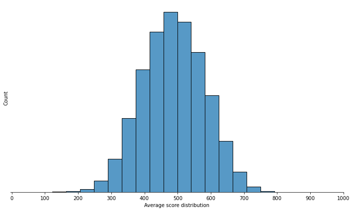

```python
f, axes = plt.subplots(1, 1, figsize=(12, 7), sharex=True)
sb.despine(left=True)
sb.histplot(df['Average Score'], bins=20);

x_ticks = np.arange(0, 1000 + 1, 100)
plt.xticks(x_ticks, x_ticks);
plt.setp(axes, yticks=[]);
plt.xlabel('Average score distribution');
```

**Inference:**

1. It seems majority of students had a score between 350 and 650.

### 5. Immigration Status

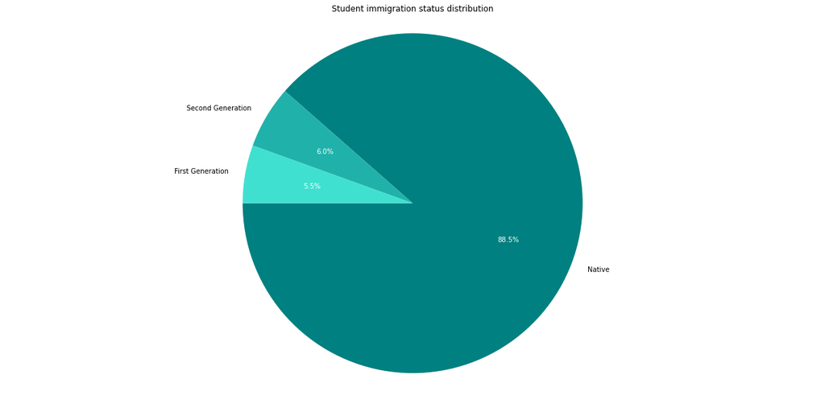

```python
fig1, ax1 = plt.subplots(1, 1, figsize=(17, 8), sharex=True)
patches, texts, autotexts = ax1.pie(df['Immigration Status'].value_counts(),
                                    colors = ['#008080','#20B2AA','#40E0D0'],
                                    labels=['Native', 'Second Generation', 'First Generation'],
                                    autopct='%1.1f%%',
                                    startangle=180
                                   );

for text in autotexts:
    text.set_color('white')

ax1.axis('equal');
plt.tight_layout();
plt.title('Student immigration status distribution')
plt.show();
```

**Inference:**

1. Most students are natives

### 6. Gender analysis

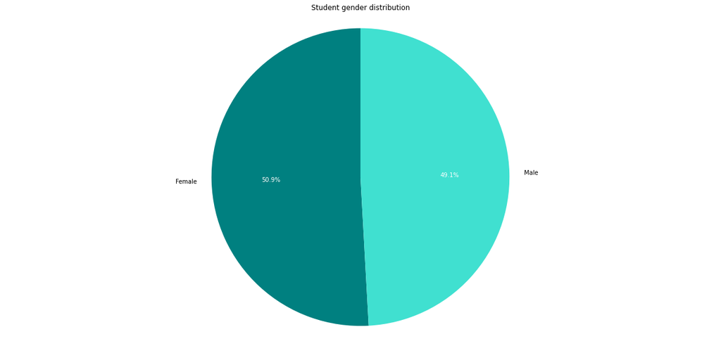

```python
fig1, ax1 = plt.subplots(1, 1, figsize=(17, 8), sharex=True)
patches, texts, autotexts = ax1.pie(df['Gender'].value_counts(),
                                    colors = ['#008080','#40E0D0'],
                                    labels=['Female','Male'],
                                    autopct='%1.1f%%',
                                    startangle=90
                                   );

for text in autotexts:
    text.set_color('white')

ax1.axis('equal');
plt.tight_layout();
plt.title('Student gender distribution')
plt.show();
```

**Inference:**

1. Both genders are of about equal proportion in the dataset

## Bivariate Exploration

### 1. Parent Presence vs Score

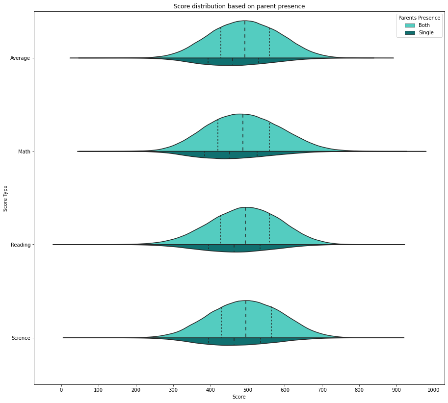

```python
data = pd.melt(df, id_vars=['Student Id', 'Gender', 'Country', 'Study Time With Parent', 'Parents Highest Education', 'Immigration Status', 'Parents Presence'],
               value_vars=['Average Score','Math Score','Reading Score','Science Score'],
               var_name="Score Type", value_name='Score')
data['Score Type'] = data['Score Type'].replace('Average Score', 'Average').replace('Math Score','Math').replace('Reading Score','Reading').replace('Science Score','Science')

palette = ["#40E0D0", "#008080"]

plt.figure(figsize = [15, 14])
ax = sb.violinplot(x = 'Score', y='Score Type', hue='Parents Presence',
                   data=data, palette=palette, split=True,
                   scale="count", inner="quartile");

x_ticks = np.arange(0, 1000 + 1, 100)
plt.xticks(x_ticks, x_ticks);
plt.title("Score distribution based on parent presence");
```

### 2. Parents level of education vs Scores

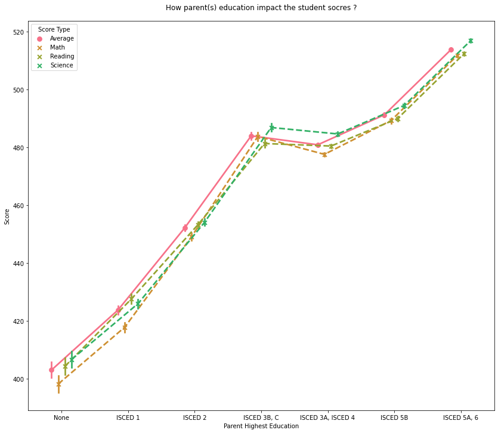

```python
parents_he_scores = df[['Parents Highest Education','Average Score','Math Score','Reading Score','Science Score']]
parents_he_scores.rename({'Average Score':'Average', 'Math Score':'Math', 'Reading Score':'Reading', 'Science Score':'Science'},axis=1, inplace=True)
data = pd.melt(parents_he_scores, id_vars=['Parents Highest Education'],
               value_vars=['Average','Math','Reading','Science'],
               var_name="Score Type", value_name='Score Value')

fig, ax = plt.subplots(1, 1, figsize=(14, 12))

ax = sb.pointplot(ax=ax, data = data,
                  x = 'Parents Highest Education', y='Score Value', hue='Score Type',
                  dodge=0.3, palette=sb.color_palette('husl', 8),
                  markers=["o", "x","x","x"], linestyles=["-", "--", "--", "--"]);

ax.set(xlabel='Parent Highest Education', ylabel='Score')
plt.title("How parent(s) education impact the student socres ?", y=1.02);
```

**Inference:**

1. Students with parents who reach upper secondary or beyond tend to perform above average
2. The higher the parent education level, the higher the student score

### 3. Study time with parent(s) vs Scores

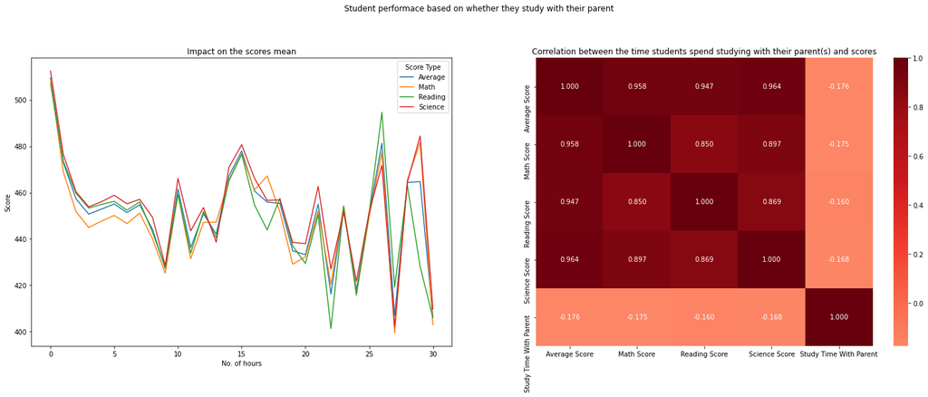

```python
scores = df.groupby(['Study Time With Parent']).mean().reset_index()[['Study Time With Parent','Average Score','Math Score','Reading Score','Science Score']]
scores.rename({'Average Score':'Average', 'Math Score':'Math', 'Reading Score':'Reading', 'Science Score':'Science'}, axis=1, inplace=True)
data = pd.melt(scores, id_vars=['Study Time With Parent'],
               value_vars=['Average','Math','Reading','Science'],
               var_name="Score Type", value_name='Score')

fig, ax = plt.subplots(1, 2, figsize=(25, 8))

sb.lineplot(ax=ax[0], data = data,
            x = 'Study Time With Parent', y='Score', hue='Score Type'
           );
ax[0].set(title='Impact on the scores mean', xlabel='No. of hours', ylabel='Score')

sb.heatmap(df[['Average Score','Math Score','Reading Score', 'Science Score', 'Study Time With Parent']].corr(), annot = True, fmt = '.3f',
           cmap = 'Reds', center = 0)
ax[1].set(title='Correlation between the time students spend studying with their parent(s) and scores')

plt.suptitle("Student performace based on whether they study with their parent", y=1.02);
```

**Inference:**

### 4. Immigration status vs Scores

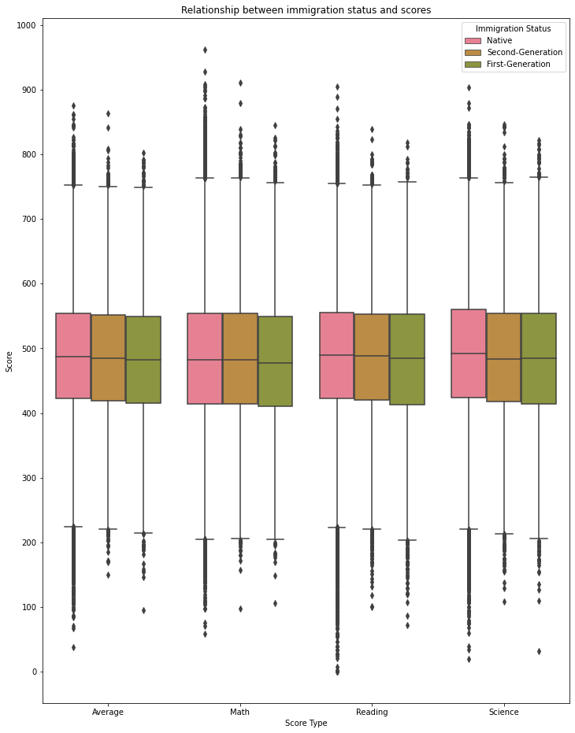

```python
data = pd.melt(df, id_vars=['Student Id', 'Gender', 'Country', 'Study Time With Parent', 'Parents Highest Education', 'Immigration Status', 'Parents Presence'],
               value_vars=['Average Score','Math Score','Reading Score','Science Score'],
               var_name="Score Type", value_name='Score')
data['Score Type'] = data['Score Type'].replace('Average Score', 'Average').replace('Math Score','Math').replace('Reading Score','Reading').replace('Science Score','Science')

plt.figure(figsize=[12, 16]);
sb.boxplot(x = data['Score Type'], y = data['Score'], hue=data['Immigration Status'], palette = sb.color_palette('husl', 8))
plt.title('Relationship between immigration status and scores');
y_ticks = np.arange(0, 1000 + 1, 100)
plt.yticks(y_ticks, y_ticks);
```

**Inference:**

1. From an overall point of view, studying seems slighly easier for native students, but the difference in score remains quite little.
2. In Math, scores are similar between native and second generation students while the one for first generation is a bit less.

## Multivariate Exploration

### 1. Parents presence vs Score vs Level of education

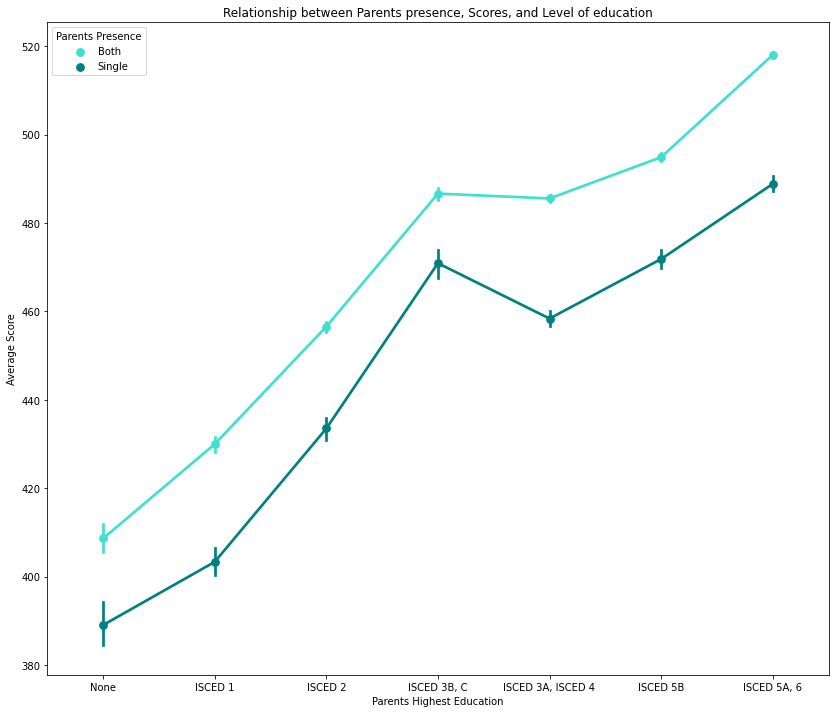

```python
plt.figure(figsize = [14, 12])
ax = sb.pointplot(data = df,
                  x = 'Parents Highest Education', y='Average Score', hue='Parents Presence',
                  palette = ["#40E0D0", "#008080"]);
plt.title('Relationship between Parents presence, Scores, and Level of education');
```

**Inference:** From the plot we can see that students with both parents with a higher level of education performed the best.

### 2. Parents presence vs Score vs Immigration status

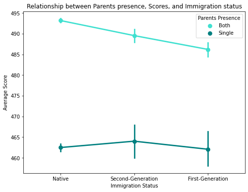

```python
plt.figure(figsize = [8, 6])

ax = sb.pointplot(data = df,
                  x = 'Immigration Status', y = 'Average Score', hue = 'Parents Presence',
                  palette = ["#40E0D0", "#008080"]
                 );

plt.title('Relationship between Parents presence, Scores, and Immigration status');
```

**Inference:** Here we observe the vast difference in scores for native students with both parents compared to native students with a single parenta.

### 3. Parents presence vs Score vs Time spent with parents

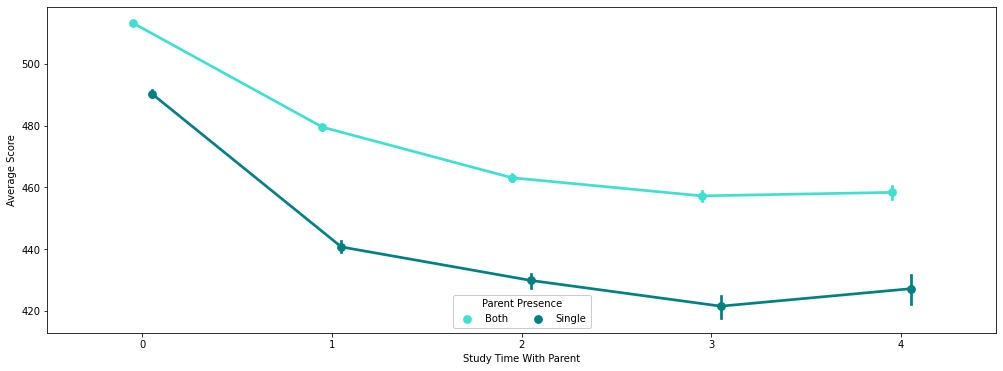

```python
plt.figure(figsize = [17, 6])

ax = sb.pointplot(data = df[df['Study Time With Parent'] < 5],
                  x = 'Study Time With Parent', y = 'Average Score', hue = 'Parents Presence',
                  dodge = 0.1, palette = ["#40E0D0", "#008080"]
                 )
ax.legend(loc = 8, ncol = 3, framealpha = 1, title = 'Parent Presence');
```

```python
df.to_csv('df_cleaned.csv')
```